# Breast Cancer Wisconsin (Diagnostic) Data Set

## by Yosef Cohen

## Investigation Overview

> Can we identify malignancy by parameters like shape and size ?

## Dataset Overview

> The dataset is from kaggle.  
> Features in the data set are computed from a digitized image of a fine needle aspirate (FNA) of a breast mass. They describe characteristics of the cell nuclei present in the image.

### There are 569 rows (cases) in the DB.

### every case has a diagnosis -

### M - for malingnant.

### B - for benign.

#### every case have data about the size and the shape of the tumor.

#### on the analysis we put our focus on the features:

```
1 radius_mean
2 texture_mean
3 perimeter_mean
4 area_mean
5 smoothness_mean
6 compactness_mean
7 concavity_mean
8 concave points_mean
9 symmetry_mean
10 fractal_dimension_mean
```

## Diagnosis

> How many malingnant and benign we have in the dataset ?

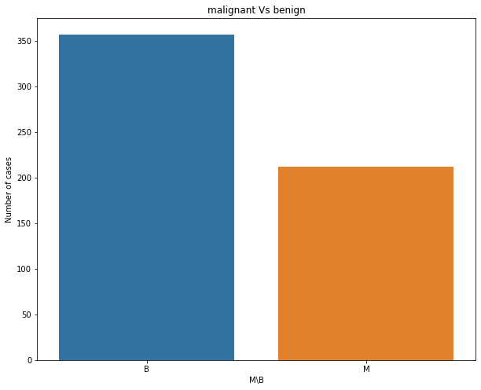

### The most cases in the dataset (above 60%) are benign.

## Connection between features and malingnancy:

## radius_mean and diagnosis

```
* we could see here overlapping between B & M.
* we could see that the overlapping is only on part of the range.
* we could see that the min,max,IQR, and the average are different between two plots.
* we could see outliers.
```

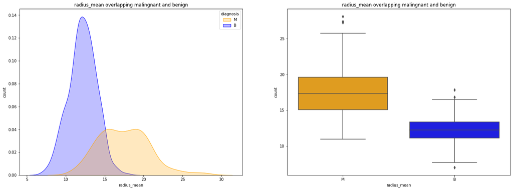

## compactness_mean and diagnosis:

```
* we could see here overlapping between B & M.
* we could see that the overlapping is only on part of the range.
* we could see that the min,max,IQR, and the average are different between two plots.
* we could see outliers.
```

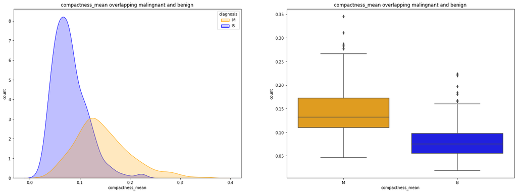

## 'concave points_mean' and diagnosis:

```
* we could see here overlapping between B & M.
* we could see that the overlapping is only on part of the range.
* we could see that the min,max,IQR, and the average are different between two plots.
* we could see outliers.
```

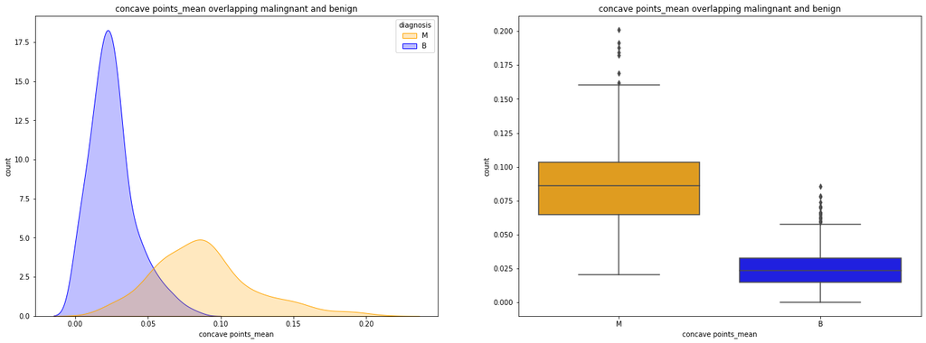

#### in comparison to the former parameters, here we see another parameter.

#### you could see that it isn't a good parameter to destinguish between B & M.

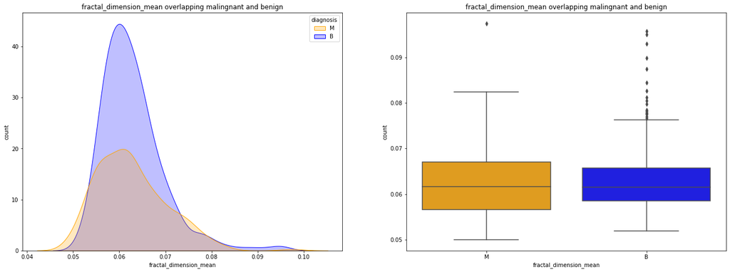

### by the end, my conclusion is:

### 1. there is a overlap in all the parameters.

### the overlap in some of them is small enough that we

### could find parameters to distinguish between malingnant and benign.

### 2. the good variables to distinguish are:

```
    * all the size variables - radius, area, perimeter.
    * compactness
    * concavity
    * concave points
```

### 3. variables which are not good enough are:

```
    * smoothness
    * symmetry
    * fractal dimetion
```

### What happens if we combine together some features ?

### is our abillity to destinguish between B & M improves ?

## radius_mean vs concave points_mean

### we could see in the plot that there is a small overlapping, but the combination of this two variables gives us pretty good ability to distinguish between B & M

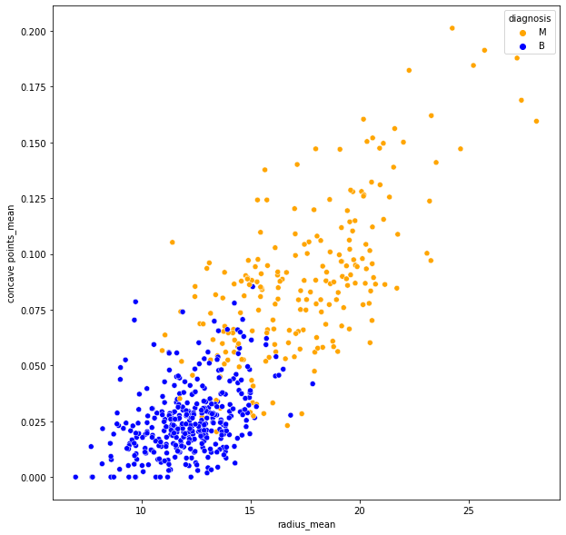

## concave points_mean vs compactness_mean

### we could see in the plot that there is a small overlapping, but the combination of this two variables gives us pretty good ability to distinguish between B & M

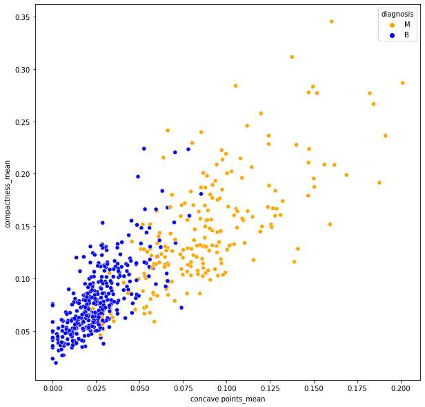

## "radius_mean" vs "smoothness_mean"

### Unlike previous examples this isn't a good combination. the difference here comes mainly from the x axis, and not from the "smoothness" parameter.

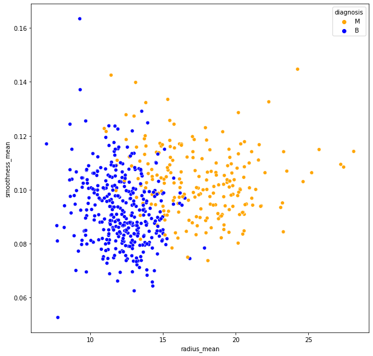

## Conclusion:

- I think that the best predictable variables are:
  1. size variables (radius,perimeter,area) - they are proportional so i prefer them as 1 variable.
  2. compactness
  3. concave points_mean & concavity - they are proportional too.
- the combination of this 3 could predict if the tumor is malingnant or benign

### the analysis of the proportions between variables is inside the full exploration analysis.